# SRM Chapter 3.4

theBudgetActuary

# Assumptions of Linear Regression

Linear Regression is a highly interpretable model. In order to trust the interpretations built from our model and make accurate predictions, a certain set of assumptions must hold. In this section we will learn to identify whether these assumptions are violated, and if so, how to correct them.

# Residual Plot

Most of the assumptions in a linear regression model can be identified by the residuals. A residual plot plots the fitted values, or $\hat{y}$, on the x-axis and the residuals (obs-pred), on the y-axis. By using a residual plot we can see for which predictor values our model is fitting well, and which predictor values our model is not.

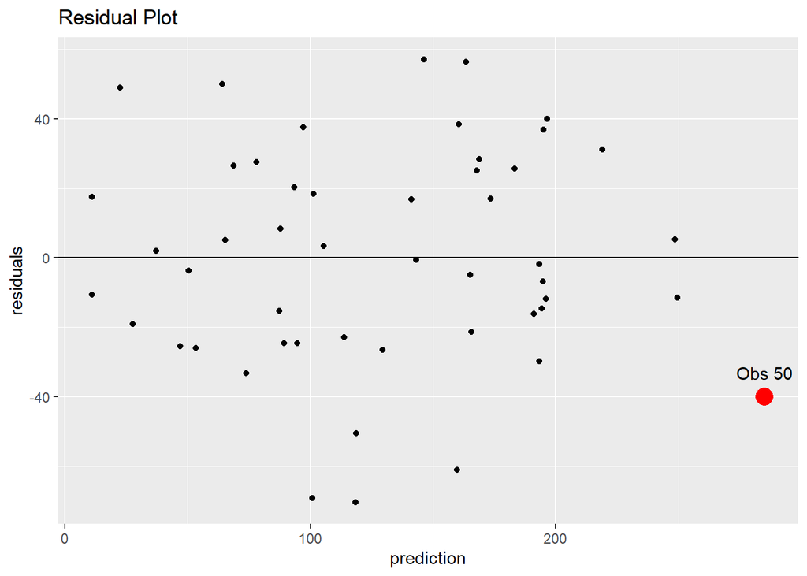

The red point in the graph is at (285,-40). This means observation 50 was given a prediction of 285 and had a residual of -40.

Since observed-predicted = residual

observed-285=-40, observed=245

So the actual value of observation 50 was 245. This means any observation below the line of having a zero residual was given a prediction that was too large. Any observation above the line was given a prediction that was smaller than its actual value.

# Assumption #1:

## Linear Relationship Between Response and Predictors

The first assumption of linear regression is that the predictors relationship with the response is linear. This can be detected with either a scatter plot or a residual plot.

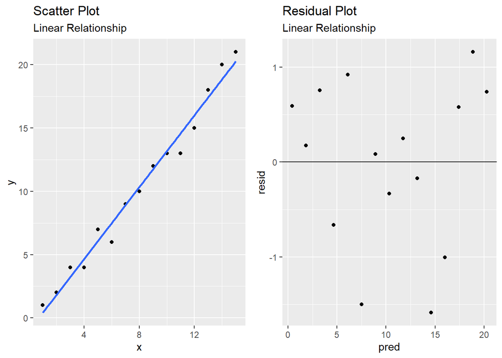

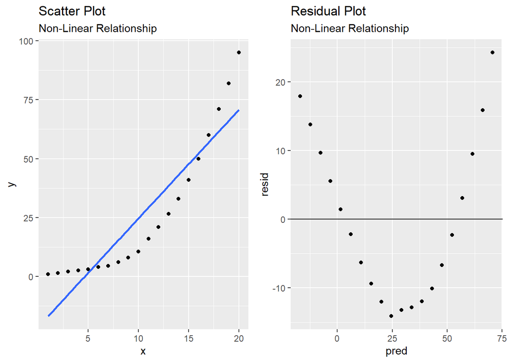

When there is a linear relationship between the predictor and the dependent variable the observations of the residual plot appear random. This is what we want to achieve. When there is a non-linear relationship between the independent and dependent variable there is a clear trend in the residual plot.

### Problems From Violating

If a predictor is included in the model that does not have a linear relationship with the dependent variable none of the estimates can be trusted. This means the coefficient estimates can be wrong, their standard errors, and the predictions.

### Solutions

We previously learned one solution to solve for non-linear relationships which is to add polynomial terms for that predictor. We can also apply different transformations such as the log(x) or $\sqrt{x}$. (James et al.)

# Assumption #2:

## Uncorrelated Error Terms

The second assumption is that the error terms are uncorrelated. This can be detected with a residual plot. This commonly occurs if trying to use linear regression on time series analysis.

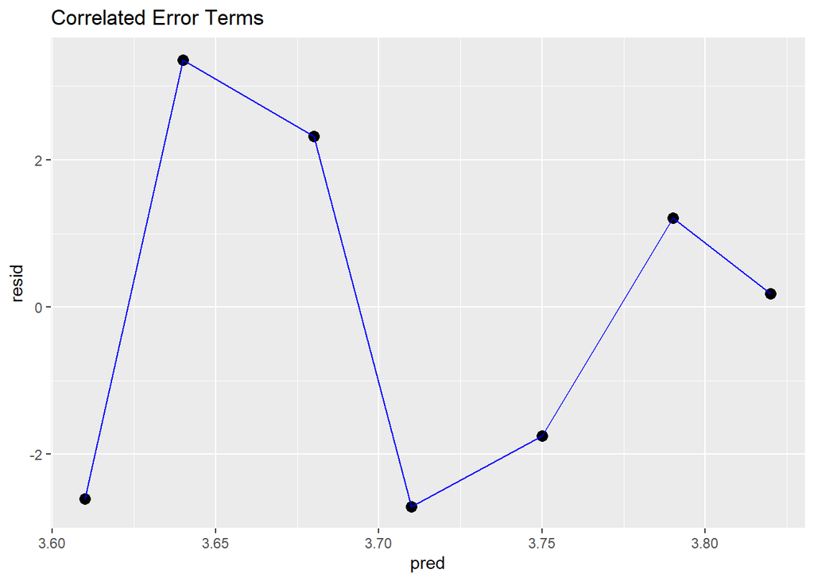

From the plot we can use the past residual to better guess the next residual. This clearly shows correlation in the error terms.

### Problems

When this problem exists the standard errors can be underestimated. In other words, we will give smaller values to the standard errors then we should. This results in narrower confidence intervals and prediction intervals then they truly are. Also, with the smaller standard errors we are less likely to drop predictors. This means it is more likely to keep predictors in our model that are not truly significant (bad predictors).

### Solutions

The most common solution is to incorporate some type of time series analysis element. (James et al.)

# Assumption #3:

## Constant Variance of Error Terms

The variance of the error terms should be constant. This means the absolute distance of the residuals from the predictions should remain constant as the prediction sizes increase. This is also known as homoscedasticity. If the variance does not stay the same this is known as heteroscedasticity. This can be identified in a residual plot.

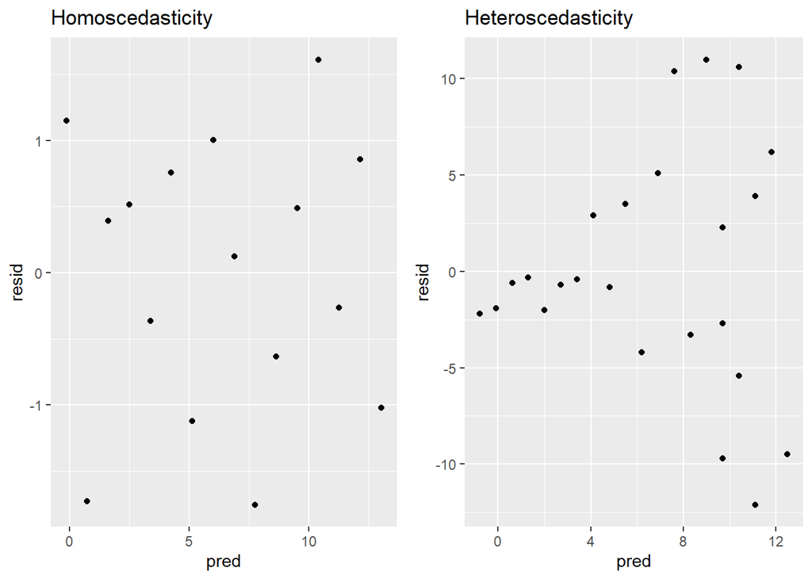

### Problems

When heteroscedasticity exists the standard errors cant be trusted. This affects the confidence intervals and hypothesis tests.

### Solutions

Heteroscedasticity can be fixed by using some type of concave function on the dependent variable such as the log(y), $\sqrt{y}$, or weighted least squares. With all these functions the dependent variables larger values are scaled down. (James et al.)

# Assumption #4:

## No Outliers

An outlier is any observation that has an unusual y value. It can be detected in a residual plot as any observation with a high absolute residual value. By using studentized residuals, which means we divide all the residuals by their combined standard deviations to set the residuals standard deviations total to 1 (Standardization will be covered next chapter). Any residual that falls more than 3 standard deviations from the mean is considered an outlier. (We will cover standardization next section)

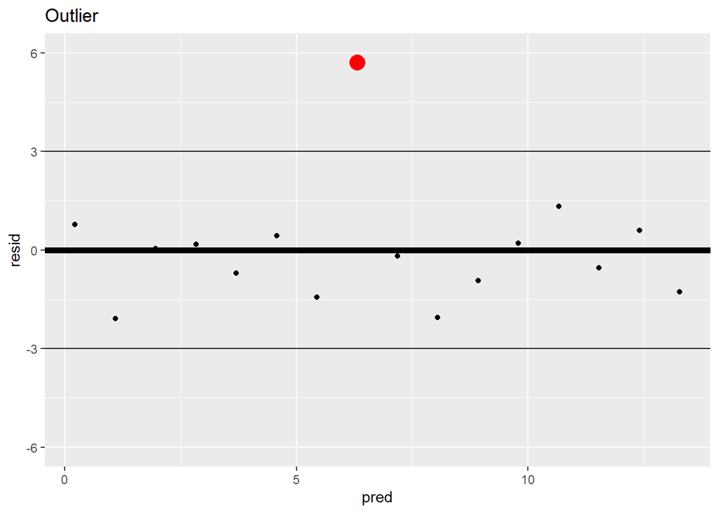

From the plot the red point is clearly over 3 standard deviations from the mean.

### Problems

If the outlier does not have an unusual x value like in the plot above, it can have little effect of the estimates of the model. However, if an observation has both an unusual x value and y value it can dramatically alter the coefficient estimates. Outliers also have an effect on the model performance metrics like MSE and $R^{2}$ where the estimates would appear much worse than if the observation was not included in the model.

### Solutions

Outliers can be caused by data entry errors in which case the observation can be dropped or changed. If not a data entry error an outlier can explained by an important predictor that is not included in the model that would help explain the unusual y value.

# Assumption #5:

## No High Leverage Points

An outlier is an unusual y value, while a high leverage point is an unusual x value. To locate simply look for predictor values that take either unusually high or low values.

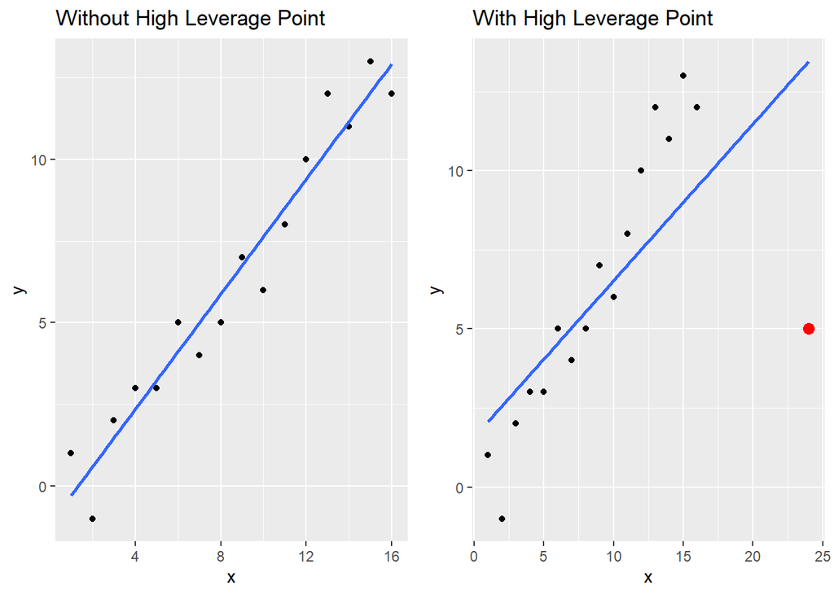

Notice that with the high leverage point the prediction line changed dramatically. A high leverage point can also be identified using the leverage statistic.

For SLR, the formula of leverage is:

Leverage=$h_{i}=\frac{1}{n}+\frac{(x_{i}-\bar{x})^{2}}{\sum_{i=1}^{n}(x_{i}-\bar{x})^{2}}$

Leverage can take any value between $\frac{1}{n}$ and 1, and the average value of the leverage is $\frac{p+1}{n}$. This means if we sum the leverage of all observations we get a value of p+1. Any observation with a leverage much higher than $\frac{p+1}{n}$ is considered a high leverage point. The effect of an observation on the prediction line can be magnified when it is both an outlier and a high leverage point.

Problems:

Can affect the coefficient estimates and predictions made by the model.

Solutions:

Remove the observation from the model, might be from a different sample space.

# Assumption #6:

## No Multicollinearity

Multicollinearity exists when two or more independent variables are closely related to each other. Since these variables increase and decrease at the same rates it can be tough to decipher the relationship for each individual independent variables effect on the dependent variable. Collinearity, which is the relation between one independent variable and another can be found with a correlation plot.

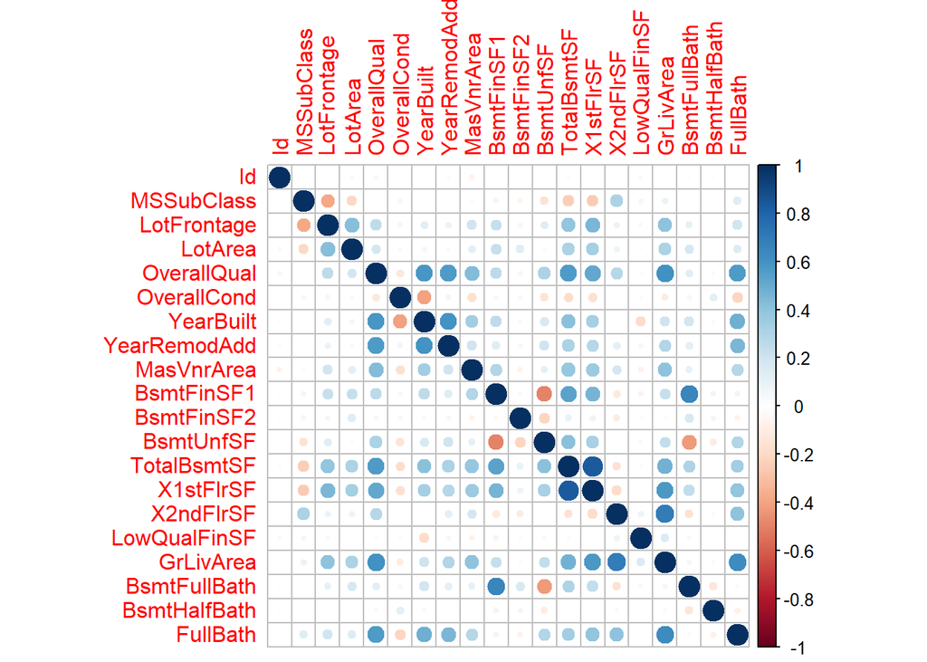

This is data from the kaggle Ames data set. Any dark blue or dark red circles represent high correlation values. For multicollinearity which can not be analyzed visually, the metric of variance inflation factor can be used. The VIF is the ratio of the variance of prediction $B_{j}$ when fit with the full model divided by the variance of $B_{j}$ is fit on its own.

$VIF = \frac{1}{1-R^{2}_{full}}$

It can take any value of 1 and up, with higher values indicating a higher multicollinearity problem. Values above 10 is evidence of high mulicollinearity.

### Problems

Reduces the accuracy of the coefficient estimates which in turn also increases the standard errors of the coefficient estimates. This makes it harder to rule predictors as statistically significant, meaning they might get dropped from the model when they should not.

### Solutions

Drop one of the problematic predictors as the information it is providing is redundant, or combine predictors that are suffering from this problem together. (James et al.)

#### Sources

James, G., Witten, D., Hastie, T., & Tibshirani, R. (n.d.). An introduction to statistical learning: With applications in R.